# Waterfowl Data Exploration

Maddee Wiggins (FlowWest)

2026-11-17

## Purpose

**Can we get Cinnamon Teal, or other waterfowl, data specifically for the Klamath Basin, in both California and Oregon?**

This document assesses each source we are given and records whether it can answer that question for each state, and at what spatial grain. Each source gets its own section after the summary.

## Summary of findings

**It is difficult to get waterfowl or Cinnamon Teal numbers for the Klamath Basin itself from the CDFW and ODFW survey data.** Both agencies report counts for survey strata that are much larger than the basin, and each survey stops at its state line.

- **California (CDFW).** The Klamath is one part of the Northeastern California stratum, which is the smallest area with Cinnamon Teal counts (28,077 in 2026). Only mallards have an index for individual segments, including the eight that cross the basin. The survey does not cover Oregon.
- **Oregon (ODFW).** The Klamath is one part of the Southeast Seasonal Marsh stratum, which also covers the Harney, Malheur and Lake basins. That stratum has 89% of Oregon’s Cinnamon Teal (26,405 in 2026). The survey does not cover California.
- **Given the use of different aircraft, counting rules and corrections for missed birds, it is unclear if we are able to combine the Oregon and California datasets.**
- **Closest match to the basin: Fleskes and Yee (2007).** For spring 2002 and 2003, they report waterfowl use in a Lower Klamath and an Upper Klamath subregion, which together held about 39% of the region’s Cinnamon Teal use (and 80% of all waterfowl use). It covers only two years, is spring migration rather than breeding, and cannot be split by state.
- **What would help.** Observation locations or segment-level counts from CDFW (segments 14-21), transect-level counts from ODFW for the Klamath and Lake county transects, and the survey-level counts behind Fleskes and Yee.

```r
tribble(
  ~Source, ~`Smallest area reported`, ~`Klamath Basin only?`, ~Years, ~`Cinnamon Teal`,
  "1. CDFW California survey", "Northeastern California stratum", "No (mallards by segment only)", "1992-2026", "Yes, by stratum",
  "2. Fleskes and Yee 2007", "Lower and Upper Klamath subregions", "Close; both states together", "Spring 2002 and 2003", "Yes, by subregion",
  "3. ODFW Oregon survey", "Southeast Seasonal Marsh stratum", "No", "1994-2026", "Yes, by stratum"
) |>
  kable()
```

| Source | Smallest area reported | Klamath Basin only? | Years | Cinnamon Teal |
| --- | --- | --- | --- | --- |
| 1. CDFW California survey | Northeastern California stratum | No (mallards by segment only) | 1992-2026 | Yes, by stratum |
| 2. Fleskes and Yee 2007 | Lower and Upper Klamath subregions | Close; both states together | Spring 2002 and 2003 | Yes, by subregion |
| 3. ODFW Oregon survey | Southeast Seasonal Marsh stratum | No | 1994-2026 | Yes, by stratum |

## Assessment by question

```r
# One row per finding. Add rows here as each new report is assessed.
# The static text is checked against the data in the section 1 chunks below,
# which stop with an error if the numbers drift.
assessments <- tribble(
  ~report, ~question, ~answer, ~detail,
  "1. CDFW breeding survey", "Cinnamon Teal counts for the California Klamath",
  "No", "Only for the Northeastern California stratum (28,077 in 2026); the Klamath is one part of it",
  "1. CDFW breeding survey", "Other waterfowl counts for the Klamath",
  "Partly", "Mallards only, at segment level (five-year average, 2014-2018); every other species is stratum-wide",
  "1. CDFW breeding survey", "Which species occur in the region",
  "Yes, regionally", "18 of 19 survey-sheet species detected in the Northeastern stratum, 2003-2015",
  "1. CDFW breeding survey", "The Oregon side of the Klamath",
  "No", "The survey covers California only",
  "1. CDFW breeding survey", "Where the survey samples the Klamath",
  "Yes", "16 flight legs and 24 waypoints; only Tule Lake and Lower Klamath refuges are crossed directly",
  "2. Fleskes and Yee 2007", "Cinnamon Teal in the Klamath, California and Oregon combined",
  "Partly", "Share of 2002-2003 spring use-days in the Lower Klamath (26%) and Upper Klamath (13%) subregions (Table 4); two years, no state split",
  "2. Fleskes and Yee 2007", "Other waterfowl species in the Klamath",
  "Yes, by subregion", "Share of use-days by species and group in the same two subregions, 2002-2003 average",
  "2. Fleskes and Yee 2007", "California vs Oregon separately",
  "No", "Subregions, not states; the Lower Klamath subregion crosses the state line",
  "3. ODFW Oregon survey 2026", "Cinnamon Teal for the Oregon Klamath",
  "No", "Only for the Southeast Seasonal Marsh stratum (26,405 in 2026, 89% of Oregon's); it also covers the Harney, Malheur and Lake basins",
  "3. ODFW Oregon survey 2026", "Other waterfowl for the Oregon Klamath",
  "No", "Same stratum for every species",
  "3. ODFW Oregon survey 2026", "Which species occur in the region",
  "Yes, regionally", "19 of 21 species in the Southeast Seasonal Marsh stratum in 2026",
  "3. ODFW Oregon survey 2026", "A time series",
  "Yes, statewide", "Cinnamon Teal index 1994-2026 (no 2001 or 2020); by stratum only for 2025, 2026 and the long-term average",
  "3. ODFW Oregon survey 2026", "The California side",
  "No", "Oregon only"
)

kable(
  assessments,
  col.names = c("Report", "Question", "Can we answer it?", "Detail")
)
```

| Report | Question | Can we answer it? | Detail |
| --- | --- | --- | --- |
| 1. CDFW breeding survey | Cinnamon Teal counts for the California Klamath | No | Only for the Northeastern California stratum (28,077 in 2026); the Klamath is one part of it |
| 1. CDFW breeding survey | Other waterfowl counts for the Klamath | Partly | Mallards only, at segment level (five-year average, 2014-2018); every other species is stratum-wide |
| 1. CDFW breeding survey | Which species occur in the region | Yes, regionally | 18 of 19 survey-sheet species detected in the Northeastern stratum, 2003-2015 |
| 1. CDFW breeding survey | The Oregon side of the Klamath | No | The survey covers California only |
| 1. CDFW breeding survey | Where the survey samples the Klamath | Yes | 16 flight legs and 24 waypoints; only Tule Lake and Lower Klamath refuges are crossed directly |
| 2. Fleskes and Yee 2007 | Cinnamon Teal in the Klamath, California and Oregon combined | Partly | Share of 2002-2003 spring use-days in the Lower Klamath (26%) and Upper Klamath (13%) subregions (Table 4); two years, no state split |
| 2. Fleskes and Yee 2007 | Other waterfowl species in the Klamath | Yes, by subregion | Share of use-days by species and group in the same two subregions, 2002-2003 average |
| 2. Fleskes and Yee 2007 | California vs Oregon separately | No | Subregions, not states; the Lower Klamath subregion crosses the state line |
| 3. ODFW Oregon survey 2026 | Cinnamon Teal for the Oregon Klamath | No | Only for the Southeast Seasonal Marsh stratum (26,405 in 2026, 89% of Oregon’s); it also covers the Harney, Malheur and Lake basins |
| 3. ODFW Oregon survey 2026 | Other waterfowl for the Oregon Klamath | No | Same stratum for every species |
| 3. ODFW Oregon survey 2026 | Which species occur in the region | Yes, regionally | 19 of 21 species in the Southeast Seasonal Marsh stratum in 2026 |
| 3. ODFW Oregon survey 2026 | A time series | Yes, statewide | Cinnamon Teal index 1994-2026 (no 2001 or 2020); by stratum only for 2025, 2026 and the long-term average |
| 3. ODFW Oregon survey 2026 | The California side | No | Oregon only |

# 1. CDFW California Waterfowl Breeding Population Survey

**Source:** [Waterfowl Breeding Population - California - 1992-2022](https://data.ca.gov/@california-department-of-fish-and-wildlife/waterfowl-breeding-population-california-1992-2022), California Department of Fish and Wildlife (CDFW), Waterfowl Program (data package `dmp000455`, saved in `data-raw/waterfowl/dmp000455_data`). CDFW asks that uses acknowledge “CA Department of Fish and Wildlife/Waterfowl Program”, funded by Pittman-Robertson and State Duck Stamp funds, and that users contact the data manager to discuss appropriate analyses.

**Also used:** Brady, C., and M. Weaver. 2026. *2026 California Waterfowl Breeding Population Survey Report*. CDFW Waterfowl Unit. PDF in `data-raw/waterfowl/reports/`. **This report was not included in the direct download from the data.ca.gov waterfowl dataset** (`dmp000455`, which ends with the 2022 report); it was provided separately.

**Temporal Coverage:** Annual, 1992-2026 (not flown in 2020 or 2021). Flown the second week of May in northeastern California (6-7 May in 2026). The annual reports in the download cover 2003-2022; the 2026 report extends the by-stratum series through 2026 (2023-2025 appear only there).

**Spatial Grain:** Stratum for counts (9 strata statewide); segment for the mallard index only. Flight legs and waypoints are mapped.

**Klamath coverage:** Partial. The Klamath is inside the Northeastern California stratum, and 16 flight legs and 24 waypoints are in the basin. California side only; no Oregon refuges.

**Species:** 19 species on the survey sheet (2003-2015); mallard, gadwall, Cinnamon Teal and Canada goose by stratum (2016-2026).

**Findings:** No Klamath-specific Cinnamon Teal counts (stratum only). Mallards have a segment-level index on all eight Klamath segments. Details below.

## What is in the folder

```r
inventory <- read_csv(
  here("data-raw", "waterfowl", "dmp000455_data_inventory.csv"),
  show_col_types = FALSE
)

inventory |>
  count(category, name = "files", sort = TRUE) |>
  kable()
```

| category | files |
| --- | --- |
| Annual population report (CA breeding waterfowl) | 18 |
| Survey area maps (images) | 11 |
| GIS data (flight segments/waypoints) | 7 |
| Annual totals report | 5 |
| BPS annual report (PDF) | 5 |
| Population estimate report | 2 |
| Program guidelines/methodology doc | 2 |
| Survey SOP reference | 1 |
| VCF criteria doc | 1 |

## How the survey works

From the CDFW metadata worksheet in the folder:

- Flown by fixed-wing aircraft and helicopter, two observers in each.
- Conducted about the third week of April in the Central Valley and the second week of May in northeastern California.
- California is divided into nine **strata**, each sampled by transects made of segments. Species, sex, and breeding status are recorded.
- The survey has run since 1955; the current design dates from 1992. It was not flown in 2020 or 2021.
- Counts are expressed as **total indicated birds** (TIB): a breeding-pair index that weights lone drakes, pairs, flocked drakes, and groups differently by species. Population estimates correct TIB for detectability using a visibility correction factor (VCF) and expand it by stratum area.
- Spatial detail: “Data collected on transect within Stratum. For some years, lat-long associated with each observation.”

## Cinnamon Teal: statewide

`cinnamon_teal_population` holds the statewide estimates compiled for this package.

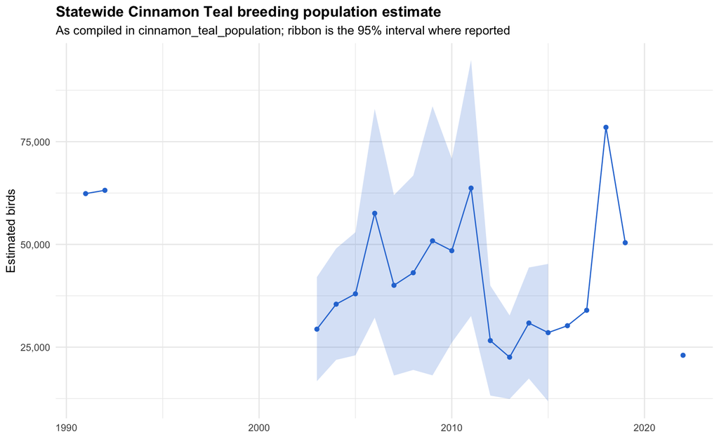

```r
cinnamon_teal_population |>
  mutate(run = cumsum(c(TRUE, diff(year) > 1))) |>   # break the line across survey gaps
  ggplot(aes(year, pop_est)) +
  geom_ribbon(aes(ymin = ci_low, ymax = ci_high, group = run), alpha = 0.2, fill = "#2a78d6", na.rm = TRUE) +
  geom_line(aes(group = run), color = "#2a78d6") +
  geom_point(color = "#2a78d6") +
  scale_y_continuous(labels = scales::comma) +
  labs(
    title = "Statewide Cinnamon Teal breeding population estimate",
    subtitle = "As compiled in cinnamon_teal_population; ribbon is the 95% interval where reported",
    x = NULL, y = "Estimated birds"
  )
```

## Cinnamon Teal: by stratum

The annual reports break the estimate down by stratum. Appendix IV of the 2026 report has Cinnamon Teal for all nine strata, 1992 to 2026. It was not in the direct download, which ends with the 2022 report, so 2023-2026 come only from the 2026 report.

```r
reports_dir <- here("data-raw", "waterfowl", "reports")

# Cinnamon Teal block of Appendix IV from a report PDF: year rows only
read_teal_appendix <- function(pdf) {
  pages <- pdf_text(pdf)
  page <- which(str_detect(pages, "Appendix IV\\. Continued") & str_detect(pages, "Cinnamon Teal"))
  stopifnot(length(page) == 1)

  lines <- strsplit(pages[page], "\n")[[1]]
  header <- str_split(trimws(grep("^\\s*Year\\s+SV", lines, value = TRUE)), "\\s+")[[1]]
  rows <- str_split(trimws(grep("^\\s*(19|20)\\d{2}\\s+\\d", lines, value = TRUE)), "\\s+")

  out <- map(rows, \(x) set_names(as.numeric(gsub(",", "", x)), header)) |>
    map(\(x) as_tibble(as.list(x))) |>
    list_rbind() |>
    rename(year = Year) |>
    mutate(ne_share = NE / TOTAL)

  # The strata should add up to the statewide total in every year.
  stopifnot(all(abs(rowSums(out[setdiff(header, c("Year", "TOTAL"))]) - out$TOTAL) <= 2))
  out
}

teal_strata <- read_teal_appendix(file.path(reports_dir, "2026 CA BPS Report Final.pdf"))
teal_strata_2022 <- read_teal_appendix(file.path(survey_dir, "2022 CA BPS Report Final.pdf"))

# Guards the numbers quoted in the text and Summary table.
stopifnot(
  range(teal_strata$year) == c(1992, 2026),
  teal_strata$NE[teal_strata$year == 2026] == 28077,
  teal_strata$TOTAL[teal_strata$year == 2026] == 39745
)
```

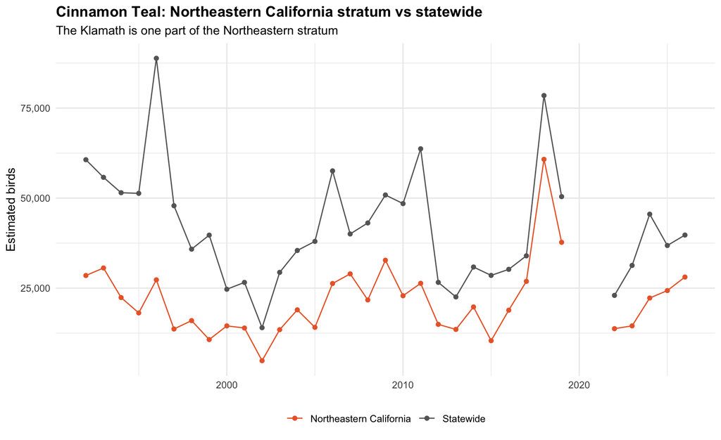

```r
teal_strata |>
  transmute(year, `Northeastern California` = NE, Statewide = TOTAL) |>
  pivot_longer(-year, names_to = "series", values_to = "estimate") |>
  mutate(run = cumsum(c(TRUE, diff(year) > 1)), .by = series) |>
  ggplot(aes(year, estimate, color = series, group = interaction(series, run))) +
  geom_line() +
  geom_point() +
  scale_y_continuous(labels = scales::comma) +
  scale_color_manual(values = c(Statewide = "grey40", `Northeastern California` = "#eb6834"), name = NULL) +
  labs(
    title = "Cinnamon Teal: Northeastern California stratum vs statewide",
    subtitle = "The Klamath is one part of the Northeastern stratum",
    x = NULL, y = "Estimated birds"
  )
```

The Northeastern stratum accounts for a median 50% of the statewide estimate (range 27% to 79%) across 33 survey years.

**2026 report vs the 2022 report.** The two appendices overlap for 1992-2022.

```r
overlap <- inner_join(
  teal_strata_2022 |> select(year, NE_2022 = NE, TOTAL_2022 = TOTAL),
  teal_strata |> select(year, NE_2026 = NE, TOTAL_2026 = TOTAL),
  by = "year"
)

overlap |>
  filter(NE_2022 != NE_2026 | TOTAL_2022 != TOTAL_2026) |>
  mutate(year = as.character(year)) |>
  kable(
    format.args = list(big.mark = ","),
    col.names = c("Year", "NE (2022 report)", "Total (2022 report)", "NE (2026 report)", "Total (2026 report)"),
    caption = "Years where the two reports differ"
  )
```

Years where the two reports differ

| Year | NE (2022 report) | Total (2022 report) | NE (2026 report) | Total (2026 report) |
| --- | --- | --- | --- | --- |
| 2022 | 13,795 | 23,028 | 13,739 | 22,983 |

```r
# Only the 2022 estimate was revised; the new years are 2023-2026.
stopifnot(
  all(overlap$year[overlap$NE_2022 != overlap$NE_2026] == 2022),
  setequal(setdiff(teal_strata$year, teal_strata_2022$year), 2023:2026)
)
```

28 of 29 overlapping years are identical for the Northeastern stratum. The 2026 report revises 2022 slightly and adds 2023-2026.

How the packaged object compares to the report appendix:

```r
object_check <- cinnamon_teal_population |>
  inner_join(teal_strata |> select(year, TOTAL), by = "year") |>
  mutate(diff = pop_est - TOTAL)

object_check |>
  filter(abs(diff) > 1) |>
  select(year, packaged = pop_est, appendix = TOTAL, diff) |>
  kable(digits = 0, caption = "Years where cinnamon_teal_population differs from Appendix IV")
```

Years where cinnamon_teal_population differs from Appendix IV

| year | packaged | appendix | diff |
| --- | --- | --- | --- |
| 1992 | 63164 | 60668 | 2496 |
| 2022 | 23028 | 22983 | 45 |

17 of 19 overlapping years match exactly. The appendix also covers 14 survey years that the packaged object lacks (1993-2026).

## Where the survey samples the Klamath

The survey’s flight legs and waypoints that fall in the Klamath Basin (the 12 HUC8 subbasins of `rivermile::klamath_hucs`), read from the KML and CSV files in the CDFW folder. These are built here for exploration and are not saved as package data.

```r
gis_dir <- file.path(
  survey_dir,
  "California Breeding Waterfowl Survey GIS info for Air Services",
  "California Breeding Waterfowl Survey GIS info for Air Services"
)

# boundaries ---------------------------------------------------------------

basin <- rivermile::klamath_hucs |>
  st_union() |>
  st_transform(5070)

# Same refuge names and 0.5-mile buffer used for `area` in this package's other datasets.
refuges_buffered <- rivermile::klamath_refuges |>
  mutate(
    area = case_when(
      str_detect(orgname, "bear valley")   ~ "Bear Valley",
      str_detect(orgname, "clear lake")    ~ "Clear Lake",
      str_detect(orgname, "klamath marsh") ~ "Klamath Marsh",
      str_detect(orgname, "lower klamath") ~ "Lower Klamath - Sheepy",
      str_detect(orgname, "tule lake")     ~ "Tule Lake",
      str_detect(orgname, "upper klamath") ~ "Upper Klamath Lake"
    )
  ) |>
  select(area) |>
  st_buffer(units::set_units(0.5, "mi")) |>
  st_transform(5070)

# Refuge (buffered) that a feature touches, or NA. A feature in the overlap of
# two buffers lists both.
refuge_of <- function(x) {
  hit <- st_intersects(st_transform(x, 5070), refuges_buffered)
  vapply(
    hit,
    \(i) if (length(i)) paste(refuges_buffered$area[i], collapse = " + ") else NA_character_,
    character(1)
  )
}

# transects ----------------------------------------------------------------
#
# The KML is a Google Earth export of the survey shapefile. Each Placemark is a
# leg between two waypoints; its Comment ends with the waypoint pair, e.g.
# "(254-255)". sf does not expose the KML's ExtendedData, so parse the XML.

kml <- read_xml(file.path(gis_dir, "California Breeding Waterfowl Survey All Segments.kml"))
xml_ns_strip(kml)

parse_leg <- function(placemark) {
  fields <- xml_find_all(placemark, ".//SimpleData")
  coords <- trimws(xml_text(xml_find_first(placemark, ".//LineString/coordinates")))
  xy <- do.call(rbind, lapply(strsplit(strsplit(coords, "\\s+")[[1]], ","), as.numeric))
  list(
    attrs = as_tibble(as.list(setNames(xml_text(fields), xml_attr(fields, "name")))),
    geom  = st_linestring(xy[, 1:2, drop = FALSE])
  )
}

legs_raw <- lapply(xml_find_all(kml, "//Placemark"), parse_leg)

legs_all <- st_sf(
  bind_rows(lapply(legs_raw, `[[`, "attrs")),
  geometry = st_sfc(lapply(legs_raw, `[[`, "geom"), crs = 4326)
)

# Keep legs that touch the basin. Source `Segment` codes are not unique and
# disagree with Str/Trn/Seg for some legs (e.g. code 090719 on segment 18), so
# key on the segment number (Seg), which matches the waypoint file and maps.
#
# The source `Length_mi` is not used. For all 106 legs statewide the geodesic
# length of the line is cos(latitude) times Length_mi (about 0.75 at the
# Klamath), as if a degree of longitude were as long as a degree of latitude.
# `length_km` below is computed from the geometry instead.
touches_basin <- lengths(st_intersects(st_transform(legs_all, 5070), basin)) > 0

legs <- legs_all[touches_basin, ]

km_in_basin <- vapply(seq_len(nrow(legs)), \(i) {
  piece <- suppressWarnings(st_intersection(st_transform(st_geometry(legs)[i], 5070), basin))
  if (length(piece) == 0) 0 else sum(as.numeric(st_length(piece))) / 1000
}, numeric(1))

wp_pair <- str_match(legs$Comment, "\\((\\d+)-(\\d+)\\)\\s*$")

klamath_legs <- legs |>
  transmute(
    stratum       = "Northeastern California",
    transect      = as.integer(Trn),
    segment       = as.integer(Seg),
    from_waypoint = as.integer(wp_pair[, 2]),
    to_waypoint   = as.integer(wp_pair[, 3]),
    description   = str_squish(str_remove(Comment, "\\(\\d+-\\d+\\)\\s*$")),
    vcf_old       = VCF == "Yes",
    vcf_2019      = New_VCF__1 == "Yes",
    length_km     = round(as.numeric(st_length(geometry)) / 1000, 2),
    km_in_basin   = round(km_in_basin, 2),
    area          = refuge_of(geometry)
  ) |>
  arrange(segment, from_waypoint)

stopifnot(
  all(legs$Str == "9"),                       # stratum 9 = Northeastern California
  !anyNA(klamath_legs$from_waypoint)
)

# waypoints ----------------------------------------------------------------

waypoints_all <- read_csv(
  file.path(gis_dir, "California Breeding Waterfowl Survey Waypoints For Plane.csv"),
  show_col_types = FALSE
)

waypoints_sf <- st_as_sf(waypoints_all, coords = c("Longitude", "Latitude"), crs = 4326, remove = FALSE)
in_basin <- lengths(st_intersects(st_transform(waypoints_sf, 5070), basin)) > 0

klamath_waypoints <- waypoints_sf[in_basin, ] |>
  transmute(
    stratum  = Strata,
    segment  = as.integer(Segment),
    waypoint = as.integer(Waypoint),
    comment  = str_squish(Comment),
    vcf_old  = `Old VCF` == "Yes",
    vcf_2019 = `New VCF (2019)` == "Yes",
    area     = refuge_of(geometry)
  ) |>
  arrange(waypoint)

stopifnot(all(klamath_waypoints$stratum == "Northeastern California"))

# Each leg should run between the two waypoints named in its comment.
wp_xy <- st_transform(waypoints_sf, 5070)
leg_end_gap_km <- vapply(seq_len(nrow(klamath_legs)), \(i) {
  leg <- st_transform(klamath_legs[i, ], 5070)
  ends <- st_cast(st_geometry(leg), "POINT")[c(1, length(st_cast(st_geometry(leg), "POINT")))]
  w <- wp_xy[match(c(leg$from_waypoint, leg$to_waypoint), waypoints_all$Waypoint), ]
  d <- st_distance(ends, st_geometry(w))
  min(sum(c(d[1, 1], d[2, 2])), sum(c(d[1, 2], d[2, 1]))) / 2 / 1000
}, numeric(1))
stopifnot(max(leg_end_gap_km) < 1)
```

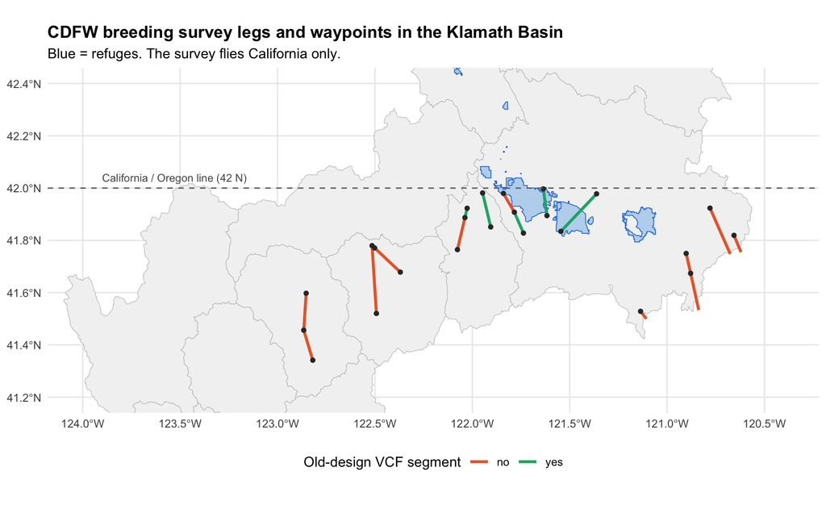

```r
hucs <- st_transform(rivermile::klamath_hucs, 4326)
refuges <- rivermile::klamath_refuges

ggplot() +
  geom_sf(data = hucs, fill = "grey95", color = "grey75", linewidth = 0.2) +
  geom_sf(data = refuges, fill = "#bcd7ee", color = "#2a78d6", linewidth = 0.3) +
  geom_sf(data = klamath_legs, aes(color = vcf_old), linewidth = 1.1) +
  geom_sf(data = klamath_waypoints, size = 1.3, color = "grey20") +
  geom_hline(yintercept = 42, linetype = "dashed", color = "grey45") +
  annotate("text", x = -123.9, y = 42.04, label = "California / Oregon line (42 N)",
           hjust = 0, size = 3, color = "grey35") +
  scale_color_manual(
    values = c(`FALSE` = "#eb6834", `TRUE` = "#1baf7a"),
    labels = c(`FALSE` = "no", `TRUE` = "yes"),
    name = "Old-design VCF segment"
  ) +
  coord_sf(xlim = c(-124, -120.4), ylim = c(41.2, 42.4)) +
  labs(
    title = "CDFW breeding survey legs and waypoints in the Klamath Basin",
    subtitle = "Blue = refuges. The survey flies California only.",
    x = NULL, y = NULL
  )
```

```r
n_legs <- nrow(klamath_legs)
n_waypoints <- nrow(klamath_waypoints)
km_in_basin <- sum(klamath_legs$km_in_basin)

# Guards the static text in the Summary table.
stopifnot(n_legs == 16, n_waypoints == 24)

# The 2026 report says transect-segment 7-20 was not flown; check it is ours.
unflown_2026 <- klamath_legs |> filter(transect == 7, segment == 20)
stopifnot(nrow(unflown_2026) == 2)
```

16 legs (208 km inside the basin) and 24 waypoints, all in the Northeastern California stratum. A **leg** runs between two waypoints; a **segment** groups one or more legs.

**2026 survey.** The 2026 report says transect-segment 7-20 in northeastern California was not flown because of high winds, leaving the survey 95% complete in that region. Segment 20 is one of the Klamath segments here (2 legs: Fort Jones (N) to E of Etna; E of Etna to N of Gallahan (S)).

## Geographic coverage: California only

```r
# The California-Oregon line is the 42nd parallel.
south_of_42 <- st_as_sfc(st_bbox(c(xmin = -125, ymin = 39, xmax = -118, ymax = 42), crs = 4326))
area_m2 <- \(x) as.numeric(st_area(st_transform(x, 5070)))

coverage <- refuges |>
  mutate(
    area = case_when(
      str_detect(orgname, "bear valley")   ~ "Bear Valley",
      str_detect(orgname, "clear lake")    ~ "Clear Lake",
      str_detect(orgname, "klamath marsh") ~ "Klamath Marsh",
      str_detect(orgname, "lower klamath") ~ "Lower Klamath - Sheepy",
      str_detect(orgname, "tule lake")     ~ "Tule Lake",
      str_detect(orgname, "upper klamath") ~ "Upper Klamath Lake"
    ),
    pct_in_california = map_dbl(seq_len(n()), \(i) {
      s <- suppressWarnings(st_intersection(st_geometry(refuges)[i], south_of_42))
      if (length(s) == 0) 0 else 100 * sum(area_m2(s)) / area_m2(st_geometry(refuges)[i])
    })
  ) |>
  st_drop_geometry() |>
  left_join(
    klamath_legs |> st_drop_geometry() |> filter(!is.na(area)) |> count(area, name = "legs_crossing"),
    by = "area"
  ) |>
  left_join(
    klamath_waypoints |> st_drop_geometry() |> filter(!is.na(area)) |> count(area, name = "waypoints_inside"),
    by = "area"
  ) |>
  mutate(across(c(legs_crossing, waypoints_inside), \(x) replace_na(x, 0L))) |>
  select(refuge = area, pct_in_california, legs_crossing, waypoints_inside)

kable(coverage, digits = 0,
      caption = "Refuge coverage by the survey (legs and waypoints use a 0.5-mile refuge buffer)")
```

Refuge coverage by the survey (legs and waypoints use a 0.5-mile refuge buffer)

| refuge | pct_in_california | legs_crossing | waypoints_inside |
| --- | --- | --- | --- |
| Bear Valley | 25 | 0 | 0 |
| Clear Lake | 100 | 0 | 0 |
| Klamath Marsh | 0 | 0 | 0 |
| Lower Klamath - Sheepy | 95 | 2 | 2 |
| Tule Lake | 94 | 1 | 1 |
| Upper Klamath Lake | 0 | 0 | 0 |

The northernmost survey waypoint is at 41.997 degrees north, so 0 of 178 waypoints are in Oregon. Upper Klamath and Klamath Marsh are entirely in Oregon and are not sampled; Bear Valley is mostly in Oregon.

## Segment-level counts: mallards only

The one segment-level count table in the folder is Appendix V of the 2019 report: a five-year average (2014-2018, fixed-wing) of mallard TIB for each of the 21 Northeastern segments.

```r
lines_2019 <- pdf_text(file.path(survey_dir, "BPS annual report 2019  Final.pdf")) |>
  paste(collapse = "\n") |>
  str_split("\n") |>
  pluck(1)

start <- grep("Appendix V\\. Five-year", lines_2019)
block <- str_match(lines_2019[start:(start + 40)], "^\\s*(\\d{1,2})\\s+([0-9.]+)\\s*(.*)$")

mallard_segments <- block[!is.na(block[, 1]) & as.integer(block[, 2]) <= 21, 2:4, drop = FALSE] |>
  as_tibble(.name_repair = "minimal") |>
  set_names(c("segment", "mallard_tib", "comment")) |>
  mutate(segment = as.integer(segment), mallard_tib = as.numeric(mallard_tib), comment = trimws(comment)) |>
  distinct(segment, .keep_all = TRUE) |>
  mutate(klamath = segment %in% 14:21, rank = rank(-mallard_tib, ties.method = "min"))

# The report's own text quotes the five-year means for segments 1, 3, 6 and 8.
stopifnot(
  nrow(mallard_segments) == 21,
  identical(mallard_segments$mallard_tib[mallard_segments$segment %in% c(1, 3, 6, 8)], c(29, 21.2, 98.6, 134.4)),
  all(mallard_segments$mallard_tib[mallard_segments$klamath] > 0)   # guards the Summary text
)
```

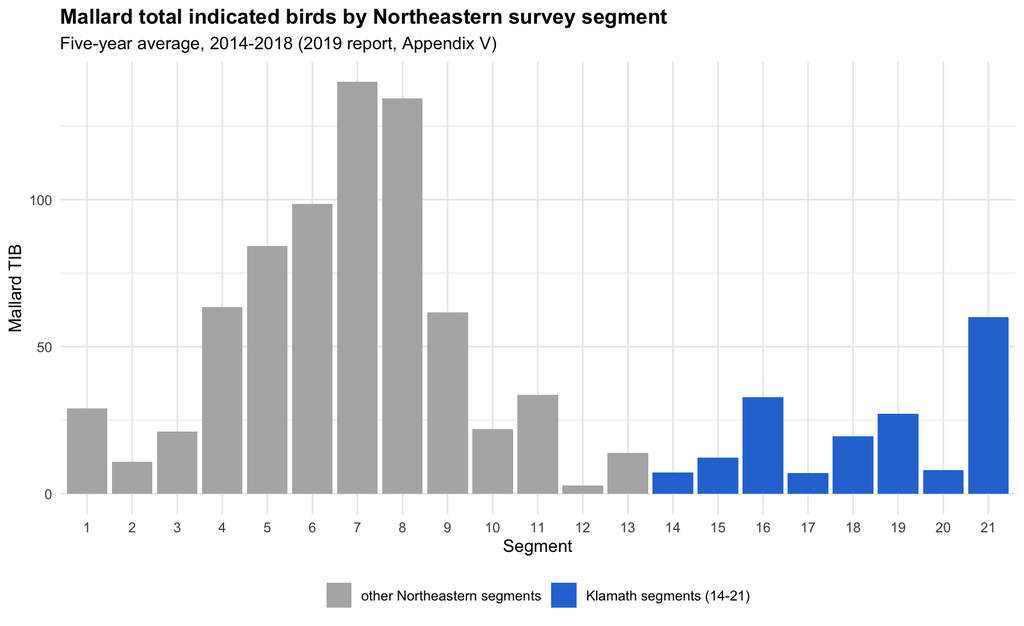

```r
ggplot(mallard_segments, aes(factor(segment), mallard_tib, fill = klamath)) +
  geom_col() +
  scale_fill_manual(values = c(`FALSE` = "grey70", `TRUE` = "#2a78d6"),
                    labels = c(`FALSE` = "other Northeastern segments", `TRUE` = "Klamath segments (14-21)"),
                    name = NULL) +
  labs(
    title = "Mallard total indicated birds by Northeastern survey segment",
    subtitle = "Five-year average, 2014-2018 (2019 report, Appendix V)",
    x = "Segment", y = "Mallard TIB"
  )
```

```r
klamath_legs |>
  st_drop_geometry() |>
  summarise(where = str_trunc(paste(unique(description), collapse = "; "), 80), .by = segment) |>
  left_join(mallard_segments |> select(segment, mallard_tib, rank), by = "segment") |>
  arrange(segment) |>
  kable(col.names = c("Segment", "Where (leg descriptions)", "Mallard TIB", "Rank of 21"),
        caption = "Klamath segments")
```

Klamath segments

| Segment | Where (leg descriptions) | Mallard TIB | Rank of 21 |
| --- | --- | --- | --- |
| 14 | Mud Lake to N of South Mtn Res. (N); Baseball Res. (N) to S of Telephone Flat… | 7.2 | 19 |
| 15 | Boles Creek (N) to N of Reservoir M | 12.2 | 16 |
| 16 | N of Reservoir M to W Fork of Witcher Crk; Beller Reservoir (S) to Spaulding … | 32.8 | 9 |
| 17 | Willow Creek Willow Creek (S); N of Sheep Mountain to NW of Dorris; W of McGa… | 7.0 | 20 |
| 18 | N of Meis Lake to SE of Ball Mountain; SE of Little Shasta (S) to N of Montague | 19.6 | 14 |
| 19 | N of Montague to Gazelle | 27.2 | 11 |
| 20 | Fort Jones (N) to E of Etna; E of Etna to N of Gallahan (S) | 8.0 | 18 |
| 21 | Tule Lake (NE) Tule Lake (SW); White Lake (N) White Lake (S) | 60.0 | 7 |

Mallards were counted on all eight Klamath segments. Together they hold 20% of the stratum’s mallard TIB while being 8 of 21 segments (mean 21.8 vs 55 for the other segments). These are whole-segment indices, not densities, and they cover mallards only.

## Species in the Northeastern stratum

The 2003-2015 reports’ “Summary B” tables give every survey-sheet species for each stratum. The Northeastern California block:

```r
report_files <- c(
  "2003" = "ca-pop2003.doc", "2004" = "ca-pop2004.doc", "2005" = "ca-pop2005.doc",
  "2006" = "ca-pop2006.doc", "2007" = "ca-pop2007.doc", "2008" = "ca-pop2008.doc",
  "2009" = "ca-pop_2009.doc", "2010" = "ca-po2010.doc", "2011" = "2011 ca_bpop_rep1.docx",
  "2012" = "2012 ca_bpop_rep1.txt", "2013" = "2013 ca_bpop_rep1.docx",
  "2014" = "2014 ca_bpop_rep1.docx", "2015" = "2015 ca_bpop_rep1.docx"
)

species_row <- "^\\s*(\\d{4})\\s+([A-Za-z][A-Za-z .'-]*?)\\s+(\\d+)\\s+(\\d+)\\s+(\\d+)\\s+\\((\\d+),\\s*([0-9?]+)\\)"

ne_species <- imap(report_files, \(file, year) {
  text <- read_report(file.path(survey_dir, file))
  header <- grep("Northeastern Cal.*\\(EF", text)[1]
  first_stratum <- str_match(text[header], "^\\s*([A-Za-z/ ]+?)\\s*\\(EF")[, 2]
  stopifnot(str_detect(first_stratum, "Northeastern"))   # NE is the first stratum on its header

  rows <- str_match(text[(header + 1):min(length(text), header + 45)], species_row)
  rows <- rows[!is.na(rows[, 1]) & !duplicated(rows[, 2]), , drop = FALSE]
  stopifnot(nrow(rows) >= 19)

  tibble(year = as.integer(year), aou = rows[1:19, 2], species = trimws(rows[1:19, 3]),
         tib = as.numeric(rows[1:19, 4]), estimate = as.numeric(rows[1:19, 5]))
}) |>
  list_rbind()

# Species names vary between reports; use the 2012 spelling for each AOU code.
ne_species <- ne_species |>
  select(-species) |>
  left_join(ne_species |> filter(year == 2012) |> select(aou, species), by = "aou")

species_summary <- ne_species |>
  summarise(
    years_detected = sum(estimate > 0),
    median_estimate = median(estimate[estimate > 0]),
    max_estimate = max(estimate),
    .by = species
  ) |>
  arrange(desc(years_detected), desc(median_estimate))

# Guards the Summary text.
stopifnot(sum(species_summary$years_detected > 0) == 18, n_distinct(ne_species$year) == 13)

species_summary |>
  mutate(across(c(median_estimate, max_estimate), \(x) round(x))) |>
  kable(
    col.names = c("Species", "Years detected (of 13)", "Median estimate when present", "Maximum estimate"),
    format.args = list(big.mark = ","),
    caption = "Northeastern California stratum, 2003-2015"
  )
```

Northeastern California stratum, 2003-2015

| Species | Years detected (of 13) | Median estimate when present | Maximum estimate |
| --- | --- | --- | --- |
| Mallard | 13 | 95,913 | 138,315 |
| American Coot | 13 | 57,709 | 170,094 |
| Gadwall | 13 | 52,874 | 128,158 |
| Canada Goose | 13 | 31,989 | 68,248 |
| Cinnamon Teal | 13 | 19,774 | 32,748 |
| Northern Shoveler | 13 | 8,193 | 43,280 |
| Northern Pintail | 13 | 3,091 | 4,649 |
| Redhead | 13 | 2,226 | 11,207 |
| Bufflehead | 13 | 1,949 | 14,778 |
| Ruddy Duck | 13 | 1,648 | 21,705 |
| American Wigeon | 13 | 1,362 | 4,019 |
| Scaup | 12 | 1,422 | 9,574 |
| Green-winged Teal | 9 | 977 | 2,301 |
| Ring-necked Duck | 8 | 1,248 | 2,381 |
| Canvasback | 8 | 598 | 3,708 |
| Goldeneye | 6 | 768 | 1,997 |
| Merganser | 6 | 498 | 1,373 |
| Wood Duck | 5 | 809 | 1,562 |
| Blue-winged Teal | 0 | NA | 0 |

```r
check <- ne_species |>
  filter(species == "Cinnamon Teal") |>
  inner_join(teal_strata |> select(year, appendix = NE), by = "year")

tibble(
  years_compared = nrow(check),
  exact_matches = sum(abs(check$estimate - check$appendix) <= 1)
) |>
  kable()
```

| years_compared | exact_matches |
| --- | --- |
| 13 | 13 |

For 2016-2022 only mallard, gadwall, Cinnamon Teal and Canada goose are broken out by stratum (Appendix IV). The stratum is much larger than the Klamath, so none of this isolates the Klamath.

## Conclusion (CDFW California)

**We cannot pull Cinnamon Teal data specific to the Klamath region of California from this dataset.**

- **Counts are by stratum.** Cinnamon Teal is estimated for the Northeastern California stratum, which also covers places such as Alturas and Susanville. The Klamath cannot be separated from it.
- **Segment-level counts are mallard-only.** Mallards were counted on all eight Klamath segments (five-year average, 2014-2018). There is nothing equivalent for Cinnamon Teal or other species, and nothing at the waypoint level.
- **California only.** The Oregon side of the basin is not surveyed. In California, flight lines cross only Tule Lake and Lower Klamath directly.
- **Finer records are not in the folder.** The metadata says observations have locations for some years, but those records were not provided.

On “waterfowl” generally: we **can** say that waterfowl occur regionally (18 of 19 survey-sheet species in the Northeastern stratum, 2003-2015) and that mallards were counted on every Klamath segment. We cannot say which other species were counted in the Klamath or how many.

**What we can provide from this report:** where the survey samples the basin, the Northeastern stratum series by species, and the mallard segment-level index.

**Next step:** ask CDFW’s Waterfowl Program (contact listed in the dataset metadata) for Cinnamon Teal and other species’ counts by segment and year for segments 14-21, plus any observation-level records with locations.

# 2. Fleskes and Yee (2007), spring waterfowl in southern Oregon and northeastern California

**Source:** Fleskes, J. P., and J. L. Yee. 2007. [Waterfowl distribution and abundance during spring migration in southern Oregon and northeastern California](https://scholarsarchive.byu.edu/wnan/vol67/iss3/10). *Western North American Naturalist* 67(3):409-428. U.S. Geological Survey, Western Ecological Research Center. Table 4 (p. 422) is the table used here. PDF in `data-raw/waterfowl/reports/`.

**Temporal Coverage:** Two springs, 5 January-3 May 2002 and 2003 (six aerial surveys each). Table 4 is the 2002-2003 average.

**Spatial Grain:** Subregion. The study area, called SONEC (southern Oregon and northeastern California; 70,491 km<sup>2</sup>), has 11 subregions. Seven core subregions plus the Madeline Plains were surveyed; Table 4 reports 7 columns. Fig. 2 of the paper shows each subregion by survey date, as bar charts without values.

**Klamath coverage:** Yes, through two subregions. *Lower Klamath* includes Lower Klamath, Tule Lake and Clear Lake NWRs, Butte Valley WA and the Klamath River State Game Management Area. *Upper Klamath* includes Upper Klamath and Klamath Marsh NWRs, Upper Klamath and Agency Lakes, and Sycan Marsh. The map (Fig. 1) shows the Lower Klamath subregion crossing the California-Oregon line, and the paper does not split it by state. These two subregions are the closest match to the Klamath Basin but are not the same boundary as the basin’s HUCs.

**Species:** Ducks (dabbling and diving, by species), geese, Tundra Swan and American Coot, including Cinnamon Teal.

**Findings:** Cinnamon Teal use-days are spread across the region, with 39% in the two Klamath subregions, compared with 80% for all waterfowl. Details below.

## Where the data come from

All counts are from aerial surveys flown for this study (pages 411-412 of the paper). The paper summarizes them; the survey-level counts are not in it.

- **Surveyors.** U.S. Fish and Wildlife Service and Oregon Department of Fish and Game biologists: Jim Hainline (Lower Klamath and Northeast California subregions, the southern part of Upper Klamath and Modoc Plateau, and Madeline Plains), and Elizabeth Huggins with Meg Laws or Marty St. Louis (Warner Valley, Summer Lake, Malheur, and the northern parts of Upper Klamath and Modoc Plateau). The authors credit >10 to >30 years of aerial survey experience.
- **Method.** Two single-engine, high-wing aircraft flew at 30-50 m and 140-150 km/hr. Where habitat blocks were large (most NWRs), pilots flew parallel transects 0.4 km (Hainline) or 0.8 km (Huggins, Laws/St. Louis) apart and counted birds within a 0.4-km swath. Small or linear habitats were flown in a track along them. Large flocks were circled. Estimated counts were dictated while flying and entered into a database.
- **Dates.** 2002: 3-5 Jan, 21-22 Feb, 13-14 Mar, 27-28 Mar, 18-19 Apr, 2-3 May. 2003: 5-6 Jan, 20-22 Feb, 12-18 Mar, 1-8 Apr, 14-18 Apr, 30 Apr-4 May. The authors standardized these to 5 Jan, 21 Feb, 13 Mar, 30 Mar, 16 Apr and 3 May.
- **From counts to Table 4.** Use-days were calculated by assuming linear change in abundance between survey dates. Average birds per day (bpd) is use-days divided by 119, the number of days in 5 January-3 May. Table 4 gives total use-days and the percent of them in each subregion.
- **Not surveyed.** Four subregions (Surprise Valley, Shasta Valley, Pueblo Valley, and Honey Lake apart from the Madeline Plains) were not surveyed. The surveyed area is 76% of SONEC’s land, 90% of its wetlands and 96% of the satellite-tagged pintail locations in 2002-2003.
- **Unpublished sources.** Earlier reports by the same group, Fleskes and Battaglia (2002, progress report; 2004, final report, USGS Western Ecological Research Center), and unpublished data cited for wetland area.
- **Funding.** Tuscany Research Institute, a Ducks Unlimited grant to the USGS Western Ecological Research Center and the California Waterfowl Association, and the USGS Science Support Program.

## Table 4

Transcribed from the paper (p. 422). “<1” and a dash are stored as missing.

```r
lt1 <- NA_real_ # the paper prints "<1"

subregions <- c(
  "Lower Klamath", "Upper Klamath", "Northeast California",
  "Modoc Plateau", "Summer Lake", "Warner Valley", "Malheur"
)

table4 <- tribble(
  ~species, ~level, ~total_use_days, ~`Lower Klamath`, ~`Upper Klamath`, ~`Northeast California`, ~`Modoc Plateau`, ~`Summer Lake`, ~`Warner Valley`, ~Malheur,
  "Dabbling ducks", "group", 68077400, 66, 12, 5, 7, 6, 4, 1,
  "Northern Pintail", "species", 32068600, 57, 15, 4, 8, 8, 6, 1,
  "Northern Shoveler", "species", 12606200, 84, 4, 4, 2, 3, lt1, 1,
  "American Wigeon", "species", 9586900, 71, 10, 6, 7, 4, 2, lt1,
  "Green-winged Teal", "species", 8355100, 74, 11, 5, 9, lt1, lt1, lt1,
  "Mallard", "species", 3222800, 67, 8, 8, 6, 7, 2, 1,
  "Gadwall", "species", 2141600, 66, 6, 13, 7, 6, 2, lt1,
  "Cinnamon Teal", "species", 96300, 26, 13, 21, 18, 17, 2, 3,
  "Wood Duck", "species", 0, NA, NA, NA, NA, NA, NA, NA,
  "Diving ducks", "group", 14538500, 49, 41, 4, 2, 3, 1, 1,
  "Ruddy Duck", "species", 4633600, 54, 41, 5, lt1, lt1, lt1, lt1,
  "Scaup", "species", 4192700, 40, 49, 5, 2, 3, lt1, lt1,
  "Bufflehead", "species", 2148400, 60, 34, 2, 3, 1, lt1, lt1,
  "Canvasback", "species", 1687200, 58, 24, 5, 3, 8, 2, lt1,
  "Mergansers", "species", 912400, 42, 52, lt1, 1, 1, 3, lt1,
  "Ring-necked Duck", "species", 687100, 36, 44, 10, 3, 7, lt1, lt1,
  "Goldeneyes", "species", 139500, 34, 53, lt1, 2, 3, 1, 7,
  "Redhead", "species", 137700, 46, 26, 8, 9, 5, 6, 1,
  "Geese", "group", 34558100, 72, 5, 7, 6, 4, 1, 5,
  "Snow Goose and Ross's Goose", "species", 17531600, 73, lt1, 5, 8, 5, lt1, 9,
  "White-fronted Goose", "species", 14973200, 79, 7, 9, 4, 1, lt1, lt1,
  "Canada Goose", "species", 2053200, 23, 20, 7, 11, 17, 12, 9,
  "Tundra Swan", "species", 2974170, 48, 22, 5, 11, 4, 9, lt1,
  "American Coot", "species", 7878900, 69, 16, 7, 3, 2, 1, 1,
  "All waterfowl", "group", 128027000, 66, 14, 6, 6, 4, 3, 2
)

# Transcription checks. Species add up to their group and the groups to the
# total (within the paper's rounding to 100), and each row's percentages add up
# to about 100 (each "<1" can hide up to 1 point).
group_of <- c(
  rep("Dabbling ducks", 8), rep("Diving ducks", 8), rep("Geese", 3),
  "Tundra Swan", "American Coot"
)
species_rows <- table4 |>
  filter(level == "species") |>
  mutate(group = group_of)

by_group <- species_rows |>
  summarise(species_sum = sum(total_use_days), .by = group) |>
  left_join(table4 |> select(group = species, reported = total_use_days), by = "group")

top_level_sum <- table4 |>
  filter(species %in% c("Dabbling ducks", "Diving ducks", "Geese", "Tundra Swan", "American Coot")) |>
  pull(total_use_days) |>
  sum()

pct_sum <- table4 |>
  filter(total_use_days > 0) |>
  select(all_of(subregions)) |>
  rowSums(na.rm = TRUE)

stopifnot(
  "species rows do not add up to their group" =
    all(abs(by_group$species_sum - by_group$reported)[by_group$group %in% c("Dabbling ducks", "Diving ducks", "Geese")] <= 200),
  "groups do not add up to All waterfowl" =
    abs(top_level_sum - table4$total_use_days[table4$species == "All waterfowl"]) <= 200,
  "row percentages do not add up to ~100" = all(abs(pct_sum - 100) <= 7)
)

table4 |>
  mutate(across(all_of(subregions), \(x) ifelse(is.na(x), ifelse(total_use_days == 0, "-", "<1"), as.character(x)))) |>
  select(-level) |>
  kable(
    format.args = list(big.mark = ","),
    col.names = c("Species or group", "Total use-days", subregions),
    align = c("l", rep("r", 8))
  )
```

| Species or group | Total use-days | Lower Klamath | Upper Klamath | Northeast California | Modoc Plateau | Summer Lake | Warner Valley | Malheur |
| --- | --- | --- | --- | --- | --- | --- | --- | --- |
| Dabbling ducks | 68,077,400 | 66 | 12 | 5 | 7 | 6 | 4 | 1 |
| Northern Pintail | 32,068,600 | 57 | 15 | 4 | 8 | 8 | 6 | 1 |
| Northern Shoveler | 12,606,200 | 84 | 4 | 4 | 2 | 3 | <1 | 1 |
| American Wigeon | 9,586,900 | 71 | 10 | 6 | 7 | 4 | 2 | <1 |
| Green-winged Teal | 8,355,100 | 74 | 11 | 5 | 9 | <1 | <1 | <1 |
| Mallard | 3,222,800 | 67 | 8 | 8 | 6 | 7 | 2 | 1 |
| Gadwall | 2,141,600 | 66 | 6 | 13 | 7 | 6 | 2 | <1 |
| Cinnamon Teal | 96,300 | 26 | 13 | 21 | 18 | 17 | 2 | 3 |
| Wood Duck | 0 | - | - | - | - | - | - | - |
| Diving ducks | 14,538,500 | 49 | 41 | 4 | 2 | 3 | 1 | 1 |
| Ruddy Duck | 4,633,600 | 54 | 41 | 5 | <1 | <1 | <1 | <1 |
| Scaup | 4,192,700 | 40 | 49 | 5 | 2 | 3 | <1 | <1 |
| Bufflehead | 2,148,400 | 60 | 34 | 2 | 3 | 1 | <1 | <1 |
| Canvasback | 1,687,200 | 58 | 24 | 5 | 3 | 8 | 2 | <1 |
| Mergansers | 912,400 | 42 | 52 | <1 | 1 | 1 | 3 | <1 |
| Ring-necked Duck | 687,100 | 36 | 44 | 10 | 3 | 7 | <1 | <1 |
| Goldeneyes | 139,500 | 34 | 53 | <1 | 2 | 3 | 1 | 7 |
| Redhead | 137,700 | 46 | 26 | 8 | 9 | 5 | 6 | 1 |
| Geese | 34,558,100 | 72 | 5 | 7 | 6 | 4 | 1 | 5 |
| Snow Goose and Ross’s Goose | 17,531,600 | 73 | <1 | 5 | 8 | 5 | <1 | 9 |
| White-fronted Goose | 14,973,200 | 79 | 7 | 9 | 4 | 1 | <1 | <1 |
| Canada Goose | 2,053,200 | 23 | 20 | 7 | 11 | 17 | 12 | 9 |
| Tundra Swan | 2,974,170 | 48 | 22 | 5 | 11 | 4 | 9 | <1 |
| American Coot | 7,878,900 | 69 | 16 | 7 | 3 | 2 | 1 | 1 |
| All waterfowl | 128,027,000 | 66 | 14 | 6 | 6 | 4 | 3 | 2 |

## Cinnamon Teal in the Klamath subregions

Cinnamon Teal is much more evenly spread than most species. The two Klamath subregions hold about 39% of its use-days, against 80% for all waterfowl.

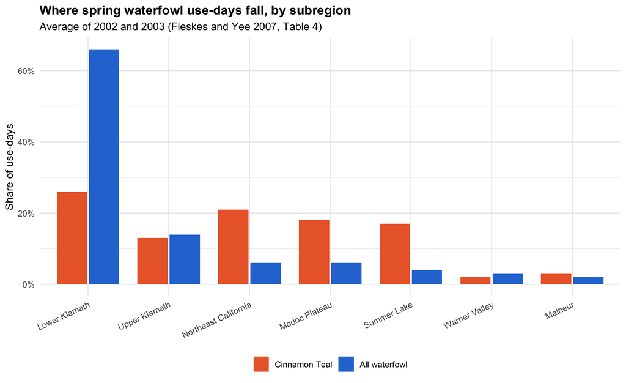

```r
dist <- table4 |>
  filter(species %in% c("Cinnamon Teal", "All waterfowl")) |>
  pivot_longer(all_of(subregions), names_to = "subregion", values_to = "pct") |>
  mutate(
    subregion = factor(subregion, levels = subregions),
    species = factor(species, levels = c("Cinnamon Teal", "All waterfowl"))
  )

ggplot(dist, aes(subregion, pct, fill = species)) +
  geom_col(position = position_dodge(width = 0.8), width = 0.75) +
  scale_fill_manual(values = c("Cinnamon Teal" = "#eb6834", "All waterfowl" = "#2a78d6"), name = NULL) +
  scale_y_continuous(labels = \(x) paste0(x, "%")) +
  labs(
    title = "Where spring waterfowl use-days fall, by subregion",
    subtitle = "Average of 2002 and 2003 (Fleskes and Yee 2007, Table 4)",
    x = NULL, y = "Share of use-days"
  ) +
  theme(axis.text.x = element_text(angle = 25, hjust = 1))
```

Average birds per day (bpd) in the two Klamath subregions, from the use-days and the 119-day season. The percentages are rounded to whole numbers, so each subregion is good to about half a point, and a “<1” is counted as 0. These are approximations.

```r
klamath <- table4 |>
  filter(total_use_days > 0) |>
  mutate(
    klamath_pct = coalesce(`Lower Klamath`, 0) + coalesce(`Upper Klamath`, 0),
    klamath_use_days = total_use_days * klamath_pct / 100,
    klamath_bpd = klamath_use_days / 119
  )

klamath |>
  transmute(
    `Species or group` = species,
    `Lower Klamath (%)` = ifelse(is.na(`Lower Klamath`), "<1", as.character(`Lower Klamath`)),
    `Upper Klamath (%)` = ifelse(is.na(`Upper Klamath`), "<1", as.character(`Upper Klamath`)),
    `Both (%)` = klamath_pct,
    `Approx. use-days` = round(klamath_use_days, -2),
    `Approx. birds per day` = round(klamath_bpd, ifelse(klamath_bpd < 1000, -1, -2))
  ) |>
  kable(format.args = list(big.mark = ","), align = c("l", rep("r", 5)))
```

| Species or group | Lower Klamath (%) | Upper Klamath (%) | Both (%) | Approx. use-days | Approx. birds per day |
| --- | --- | --- | --- | --- | --- |
| Dabbling ducks | 66 | 12 | 78 | 53,100,400 | 446,200 |
| Northern Pintail | 57 | 15 | 72 | 23,089,400 | 194,000 |
| Northern Shoveler | 84 | 4 | 88 | 11,093,500 | 93,200 |
| American Wigeon | 71 | 10 | 81 | 7,765,400 | 65,300 |
| Green-winged Teal | 74 | 11 | 85 | 7,101,800 | 59,700 |
| Mallard | 67 | 8 | 75 | 2,417,100 | 20,300 |
| Gadwall | 66 | 6 | 72 | 1,542,000 | 13,000 |
| Cinnamon Teal | 26 | 13 | 39 | 37,600 | 320 |
| Diving ducks | 49 | 41 | 90 | 13,084,600 | 110,000 |
| Ruddy Duck | 54 | 41 | 95 | 4,401,900 | 37,000 |
| Scaup | 40 | 49 | 89 | 3,731,500 | 31,400 |
| Bufflehead | 60 | 34 | 94 | 2,019,500 | 17,000 |
| Canvasback | 58 | 24 | 82 | 1,383,500 | 11,600 |
| Mergansers | 42 | 52 | 94 | 857,700 | 7,200 |
| Ring-necked Duck | 36 | 44 | 80 | 549,700 | 4,600 |
| Goldeneyes | 34 | 53 | 87 | 121,400 | 1,000 |
| Redhead | 46 | 26 | 72 | 99,100 | 830 |
| Geese | 72 | 5 | 77 | 26,609,700 | 223,600 |
| Snow Goose and Ross’s Goose | 73 | <1 | 73 | 12,798,100 | 107,500 |
| White-fronted Goose | 79 | 7 | 86 | 12,877,000 | 108,200 |
| Canada Goose | 23 | 20 | 43 | 882,900 | 7,400 |
| Tundra Swan | 48 | 22 | 70 | 2,081,900 | 17,500 |
| American Coot | 69 | 16 | 85 | 6,697,100 | 56,300 |
| All waterfowl | 66 | 14 | 80 | 102,421,600 | 860,700 |

```r
# Guards the static text above.
ct <- klamath |> filter(species == "Cinnamon Teal")
aw <- klamath |> filter(species == "All waterfowl")
stopifnot(
  "Cinnamon Teal Klamath share is not 39%" = ct$klamath_pct == 39,
  "All waterfowl Klamath share is not 80%" = aw$klamath_pct == 80,
  "Cinnamon Teal bpd is not about 300" = round(ct$klamath_bpd, -2) == 300
)
```

## Cautions

- **Two years.** This is a 2002-2003 snapshot, with the 2002-2003 average used for Table 4. It says nothing about trends.
- **Spring migration, not breeding.** The surveys run 5 January-3 May and include migrants passing through. They are not the CDFW May breeding index in section 1, so it is unclear if the two can be combined or compared directly.
- **No state split.** Upper Klamath is north of the state line in Fig. 1, but Lower Klamath crosses it, so California and Oregon cannot be separated.
- **Detection.** The authors note that drab waterfowl in small groups in vegetated habitat were probably missed more often (p. 426), which is a concern for Cinnamon Teal. The counts are pseudo-censuses with no precision estimates.
- **Percentages are rounded**, and “<1” cells are unknown.

## Conclusion (Fleskes and Yee)

**We can say where Cinnamon Teal spent the spring in 2002-2003 across subregions, and that about 39% of its use-days were in the Lower and Upper Klamath subregions.** We cannot give California and Oregon separately, a time series, or counts for the Klamath Basin boundary itself.

# 3. ODFW Oregon Breeding Waterfowl Population Survey, 2026

**Source:** Walton, K., and B. Reishus. 2026. *2026 Oregon Breeding Waterfowl Population Report*. Oregon Department of Fish and Wildlife (ODFW), Migratory Game Bird Program. PDF (34 pages) in `data-raw/waterfowl/reports/`; add a link here if the report is posted online.

**Temporal Coverage:** Annual, 1994-2026, except 2001 and 2020. The 2026 survey was flown April 27-29 in western Oregon and May 8-14 in eastern Oregon. Statewide estimates by species are given for every year (Appendix C). Estimates by stratum are given only for 2026, 2025 and the long-term average (LTA, the mean of 1994-2025).

**Spatial Grain:** Stratum. Oregon has five strata and the report gives each species’ estimate for each, plus a statewide total. Flight transects are mapped (Fig. 1), but observations by location are not published.

**Klamath coverage:** Partial, and Oregon only. The *Southeast Seasonal Marsh* stratum includes Upper Klamath, Lower Klamath, Klamath Marsh, the Sprague River Valley and Sycan Marsh, together with many other basins in Lake, Harney and Malheur counties (Summer Lake, Warner Valley, Catlow Valley, Harney Basin, and others). The Klamath cannot be separated from them. The *Forested Wetlands* stratum runs along the California border north to about Quartz Mountain. The survey does not cover California.

**Species:** 21 duck, goose, coot and crane species or groups, including Cinnamon Teal. Species that do not breed in Oregon (for example tundra swan and white geese) are ignored.

**Findings:** Cinnamon Teal can be reported for the Southeast Seasonal Marsh stratum, which holds 89% of Oregon’s. Nothing finer. Details below.

## Where the data come from

The counts come from ODFW’s own helicopter survey, described on pages 2-5 of the report.

- **Surveyors.** Two ODFW biologists per flight crew, with a contracted helicopter and pilot (a Bell 206 B3 flown by JL Aviation Inc. since 2014). The Klamath and Lake counties and southern Harney County were flown by one crew (Appendix A).
- **Method.** Transects run through each stratum and are ¼ mile wide (660 feet each side of the centerline), covering about 4-5% of each stratum. The helicopter flies at 100-200 feet. Observers record every bird on voice recorders, with GPS tablets showing the transect boundaries, and the pilot loops back or hovers so the observers can try to count everything. Since 2004 all surveys have been flown by helicopter, detection is treated as complete, and no visibility correction is applied.
- **Counting rules.** Ducks are classed as pairs, lone drakes, lone hens (for four diving species only), grouped drakes and flocks. A lone drake or group of 2-4 drakes is doubled to account for an unseen hen (“total indicated birds”). Larger groups of drakes are flocks and are not doubled.
- **To a population index.** Counts per transect are expanded by transect length and stratum area to a stratum estimate, and the strata are summed. It is an index, not absolute abundance. For eastern Oregon, flocks are included, which differs from California, which ignores flocked shovelers entirely (p. 7).

## Cinnamon Teal

Transcribed from Appendix B (stratum table, p. 16) and Appendix C (annual estimates, p. 32).

```r
or_teal_strata <- tribble(
  ~stratum, ~est_2026, ~est_2025, ~lta,
  "Southeast Seasonal Marsh", 26405, 20662, 25965,
  "Northeast Seasonal Marsh", 2160, 1198, 3991,
  "Forested Wetlands", 259, 43, 296,
  "Willamette Valley", 619, 697, 1552,
  "Lower Columbia River", 295, 164, 490
)

or_teal_year <- tribble(
  ~year, ~estimate, ~se,
  1994, 75169, 12476,
  1995, 40620, 6141,
  1996, 34589, 4086,
  1997, 49027, 7278,
  1998, 47442, 6134,
  1999, 44810, 6455,
  2000, 60276, 8041,
  2002, 38307, 5416,
  2003, 40310, 6385,
  2004, 31488, 4282,
  2005, 31429, 4963,
  2006, 22195, 3093,
  2007, 33828, 3980,
  2008, 23929, 3849,
  2009, 20683, 2720,
  2010, 24868, 4419,
  2011, 16894, 2509,
  2012, 23725, 3743,
  2013, 19350, 3132,
  2014, 31250, 5590,
  2015, 35674, 6682,
  2016, 23422, 4050,
  2017, 30309, 4733,
  2018, 37459, 7279,
  2019, 32604, 4846,
  2021, 26609, 4916,
  2022, 22059, 3736,
  2023, 11172, 1750,
  2024, 16541, 2297,
  2025, 22764, 4028,
  2026, 29738, 4908
)

# Transcription checks against the report's own totals and averages.
stopifnot(
  "strata do not add up to the statewide 2026 estimate" =
    abs(sum(or_teal_strata$est_2026) - 29738) <= 2,
  "annual series does not match the report's 2026 estimate" =
    or_teal_year$estimate[or_teal_year$year == 2026] == 29738,
  "mean of 1994-2025 does not match the report's LTA of 32,293" =
    abs(mean(or_teal_year$estimate[or_teal_year$year <= 2025]) - 32293) < 1,
  "2001 and 2020 should be absent" = !any(c(2001, 2020) %in% or_teal_year$year)
)

or_teal_strata |>
  mutate(share_2026 = est_2026 / sum(est_2026)) |>
  kable(
    format.args = list(big.mark = ","),
    digits = 2,
    col.names = c("Stratum", "2026", "2025", "LTA (1994-2025)", "Share of 2026 total"),
    align = c("l", rep("r", 4))
  )
```

| Stratum | 2026 | 2025 | LTA (1994-2025) | Share of 2026 total |
| --- | --- | --- | --- | --- |
| Southeast Seasonal Marsh | 26,405 | 20,662 | 25,965 | 0.89 |
| Northeast Seasonal Marsh | 2,160 | 1,198 | 3,991 | 0.07 |
| Forested Wetlands | 259 | 43 | 296 | 0.01 |
| Willamette Valley | 619 | 697 | 1,552 | 0.02 |
| Lower Columbia River | 295 | 164 | 490 | 0.01 |

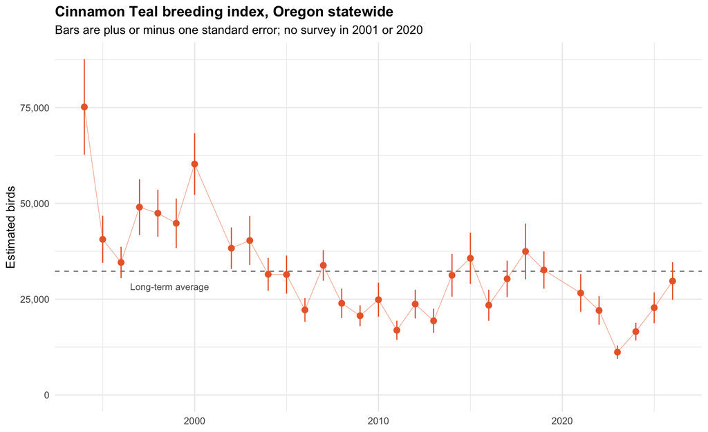

```r
lta <- mean(or_teal_year$estimate[or_teal_year$year <= 2025])

ggplot(or_teal_year, aes(year, estimate)) +
  geom_hline(yintercept = lta, color = "grey50", linetype = "dashed") +
  geom_pointrange(
    aes(ymin = estimate - se, ymax = estimate + se),
    color = "#eb6834", size = 0.4
  ) +
  geom_line(color = "#eb6834", linewidth = 0.3, alpha = 0.5) +
  annotate("text", x = 1996.5, y = lta - 4000, label = "Long-term average", hjust = 0, size = 3, color = "grey35") +
  scale_y_continuous(labels = scales::comma, limits = c(0, NA)) +
  labs(
    title = "Cinnamon Teal breeding index, Oregon statewide",
    subtitle = "Bars are plus or minus one standard error; no survey in 2001 or 2020",
    x = NULL, y = "Estimated birds"
  )
```

The Southeast Seasonal Marsh stratum has about 89% of Oregon’s Cinnamon Teal (26,405 of 29,738 in 2026, with a long-term average of 25,965), so the statewide series mostly reflects it. Series by stratum are not published, only the three values above.

## Other waterfowl in the Southeast Seasonal Marsh stratum

Estimates for the stratum that contains the Oregon Klamath, for 2026, with the statewide total for comparison.

```r
or_se_species <- tribble(
  ~species, ~se_marsh, ~statewide,
  "Mallard", 41079, 75668,
  "Gadwall", 50685, 62948,
  "American Wigeon", 204, 1362,
  "Green-winged Teal", 204, 1191,
  "Blue-winged Teal", 41, 169,
  "Cinnamon Teal", 26405, 29738,
  "Northern Shoveler", 8236, 10131,
  "Northern Pintail", 817, 1162,
  "Wood Duck", 82, 3096,
  "Redhead", 4414, 5639,
  "Canvasback", 1206, 1206,
  "Scaup", 2309, 4031,
  "Ring-necked Duck", 2146, 4727,
  "Goldeneye", 0, 0,
  "Bufflehead", 1635, 2628,
  "Ruddy Duck", 3004, 5015,
  "Common Merganser", 715, 886,
  "Hooded Merganser", 0, 0,
  "Canada Goose", 24504, 45579,
  "American Coot", 64909, 69144,
  "Sandhill Crane", 1104, 1661
)

# Statewide values should match Table 1 (p. 6); the stratum cannot exceed them.
stopifnot(
  "a stratum estimate exceeds its statewide estimate" =
    all(or_se_species$se_marsh <= or_se_species$statewide),
  "Table 1 spot check failed" =
    or_se_species$statewide[or_se_species$species == "Mallard"] == 75668 &&
      or_se_species$statewide[or_se_species$species == "Canada Goose"] == 45579,
  "Cinnamon Teal rows disagree" =
    or_se_species$se_marsh[or_se_species$species == "Cinnamon Teal"] == or_teal_strata$est_2026[1],
  "Summary text says 19 of 21 species were present" =
    sum(or_se_species$se_marsh > 0) == 19 && nrow(or_se_species) == 21
)

or_se_species |>
  mutate(share = se_marsh / statewide) |>
  kable(
    format.args = list(big.mark = ","),
    digits = 2,
    col.names = c("Species", "Southeast Seasonal Marsh", "Oregon total", "Share of Oregon total"),
    align = c("l", "r", "r", "r")
  )
```

| Species | Southeast Seasonal Marsh | Oregon total | Share of Oregon total |
| --- | --- | --- | --- |
| Mallard | 41,079 | 75,668 | 0.54 |
| Gadwall | 50,685 | 62,948 | 0.81 |
| American Wigeon | 204 | 1,362 | 0.15 |
| Green-winged Teal | 204 | 1,191 | 0.17 |
| Blue-winged Teal | 41 | 169 | 0.24 |
| Cinnamon Teal | 26,405 | 29,738 | 0.89 |
| Northern Shoveler | 8,236 | 10,131 | 0.81 |
| Northern Pintail | 817 | 1,162 | 0.70 |
| Wood Duck | 82 | 3,096 | 0.03 |
| Redhead | 4,414 | 5,639 | 0.78 |
| Canvasback | 1,206 | 1,206 | 1.00 |
| Scaup | 2,309 | 4,031 | 0.57 |
| Ring-necked Duck | 2,146 | 4,727 | 0.45 |
| Goldeneye | 0 | 0 | NaN |
| Bufflehead | 1,635 | 2,628 | 0.62 |
| Ruddy Duck | 3,004 | 5,015 | 0.60 |
| Common Merganser | 715 | 886 | 0.81 |
| Hooded Merganser | 0 | 0 | NaN |
| Canada Goose | 24,504 | 45,579 | 0.54 |
| American Coot | 64,909 | 69,144 | 0.94 |
| Sandhill Crane | 1,104 | 1,661 | 0.66 |

Nineteen of the 21 species were present in the stratum in 2026; goldeneye and hooded merganser were not recorded anywhere in the state.

## Cautions

- **Stratum, not Klamath.** The stratum is far larger than the Klamath Basin and mixes in other basins (Harney, Malheur, Lake). The report’s flight crew assignments (Appendix A) group Klamath and Lake counties together as well.
- **An index, not abundance.** Transects cover 4-5% of each stratum and the estimates are described as an index of breeding waterfowl.
- **Cinnamon Teal are probably undercounted.** The report says crews believe they are detected less often than other species because of dark coloring and their use of flooded emergent vegetation (p. 7).
- **Large flocks swing the stratum estimates**, mainly shoveler and gadwall in the Southeast Seasonal Marsh. The report notes it is not known whether these birds are breeders or late migrants.
- **Habitat in 2026.** Snowpack was record or near-record low in the Klamath basin, though wetland conditions in Klamath, Lake and Harney counties were fair (p. 6).
- **Comparing to section 1.** Both are May breeding surveys, but the two states use different methods (Oregon: helicopter with no visibility correction; California: mostly fixed-wing plane, with visibility correction factors, and no flocked shovelers). It is unclear if their numbers can be combined.

## Conclusion (ODFW Oregon)

**We cannot pull Cinnamon Teal or other waterfowl data specific to the Oregon Klamath from this report.** Counts are by stratum, and the stratum that holds the Klamath is much larger than the basin. What we can provide is the annual statewide Cinnamon Teal index from 1994 to 2026, its 2026 value by stratum, and the 2026 estimates for all species in the Southeast Seasonal Marsh stratum.

**Next step:** ask ODFW’s Migratory Game Bird Program (the report’s authors) for transect-level counts or observation locations for the Klamath and Lake county transects (Appendix A: flown by one crew), which could be summarized for the Klamath Basin.

# Additional reports

## 4. (to be added)

**Source:**

**Temporal Coverage:**

**Spatial Grain:**

**Klamath coverage:**

**Species:**

**Findings:**